# Predicting anime rating with logistic regression

Minna Peralampi: minna.peralampi@helsinki.fi

8.3.2017

# Abstract

In this analysis we will predict anime rating based on genre, members, number of episodes and anime type. First we look into the variables, then we make the model and validate it with odds ratios and cross tabulation.

# Research questions

##### Can we predict if the anime is popular based on the number of episoeds, genres, members and type?

##### My hypothesis is that more episodes and members makes the anime more likely to be liked. Mystery/sci-fi - genre animes would be the most liked ones.

## Link to the R-script

https://github.com/minna4125/IODS-final/blob/master/create_anime.R

# The data

#### The data is downloaded from kaggele (2.3.2017).

https://www.kaggle.com/CooperUnion/anime-recommendations-database It orgins from myanimelist.net website. Data is about animes ratings in myanimelist.net.

##### Variables in the data:

Data modification 1.Animes with NA values were removed (such as animes with no genre or type) 2.44 genres were reduced to 5 clusters 3.Anime_ids were made to a rownames 4.Rating was made into a binomial variable

# Variables

```r
    #Downloading the data
    anime <- read.csv("anime_gen", stringsAsFactors = F)

    #Changing the type variable to factor (=fixing an evil elf problem)
    anime$type <- as.factor(anime$type)
    #Checking the structure of the data
    str(anime)
```

```
## 'data.frame':    11830 obs. of  7 variables:
##  $ X            : int  1 2 3 4 5 6 7 8 9 10 ...
##  $ name         : chr  "Kimi no Na wa." "Fullmetal Alchemist: Brotherhood" "GintamaÂ°" "Steins;Gate" ...
##  $ type         : Factor w/ 6 levels "Movie","Music",..: 1 6 6 6 6 6 6 4 1 6 ...
##  $ episodes     : int  1 64 51 24 51 10 148 110 1 13 ...
##  $ rating       : int  1 1 1 1 1 1 1 1 1 1 ...
##  $ members      : int  200630 793665 114262 673572 151266 93351 425855 80679 72534 81109 ...
##  $ genre_cluster: int  4 1 5 2 5 3 5 4 5 5 ...
```

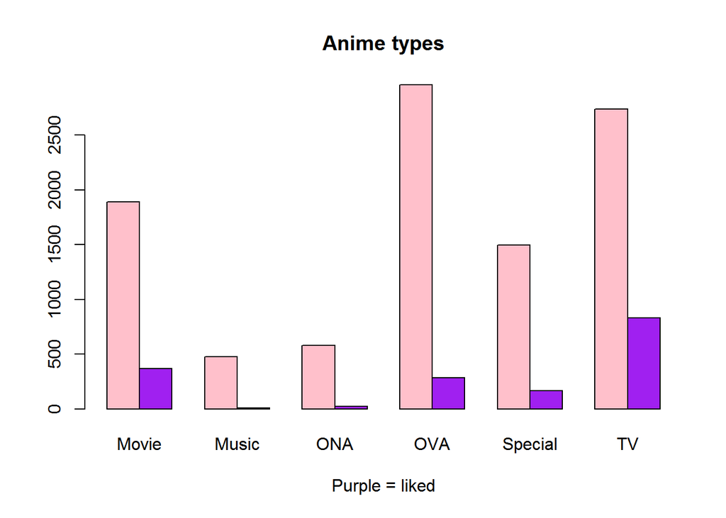

```r
    #Drawing the type variable
    counts <- table(anime$rating, anime$type)
    barplot(counts , main="Anime types", xlab = "Purple = liked", col=c( "pink", "purple"), beside = T)
```

```r
    #Printing out the numbers
    counts
```

```
##
##     Movie Music  ONA  OVA Special   TV
##   0  1890   477  581 2960    1498 2737
##   1   368    10   25  286     167  831
```

###### TV and Movie types are the most popular (=more out of them is being liked) than the others.

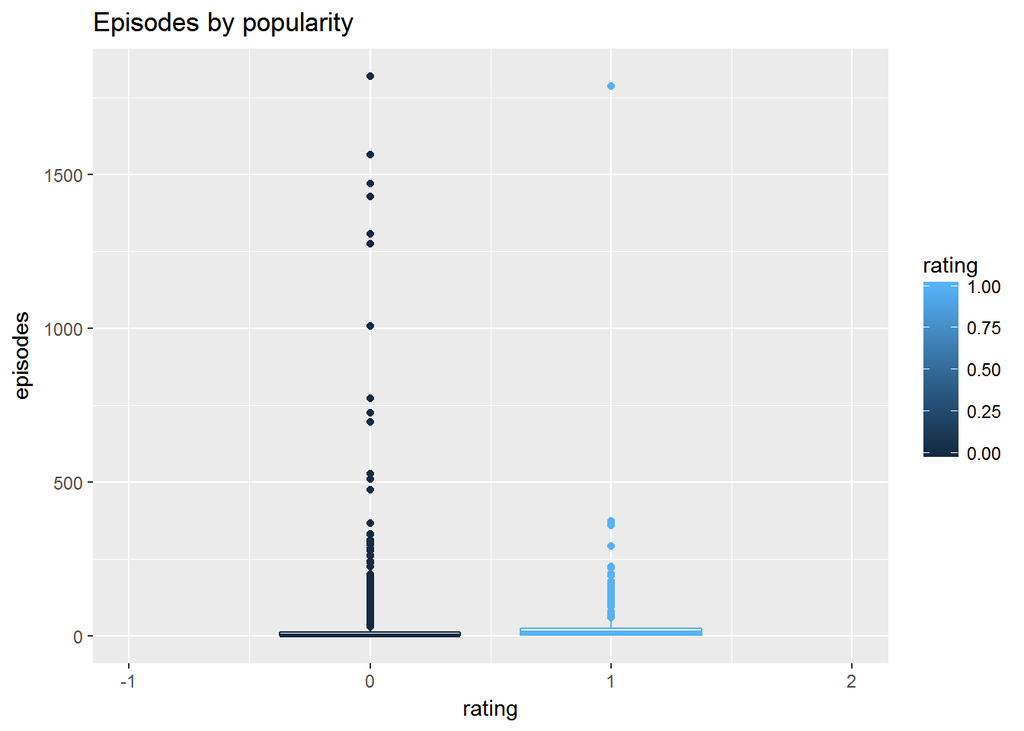

```r
    #Adding library
    library(ggplot2)


    #Drawing the episodes variable
    g2 <- ggplot(anime, aes(x = rating, y = episodes, group = rating, col=rating))

    #Defining the plot as a boxplot and drawing it
    g2 + geom_boxplot() + ylab("episodes") + ggtitle("Episodes by popularity")+ xlim(-1,2)
```

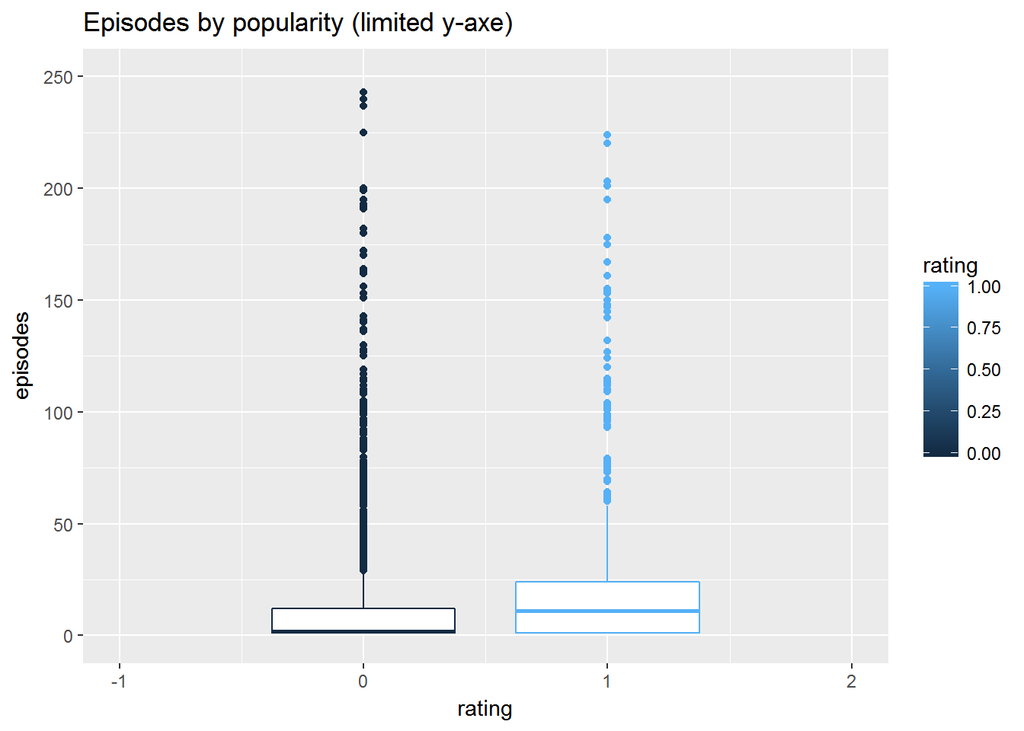

```r
    #Defining the plot as a boxplot and drawing it with limited y axis
    g2 + geom_boxplot() + ylab("episodes") + ggtitle("Episodes by popularity (limited y-axe)")+ xlim(-1,2)+ylim(0,250)
```

###### Dissliked anime has more animes at the over 1000 episodes. From this we could say that people don’t generally like animes that are made longer and longer and longer. In most cases popular animes have more episodes than the dissliked animes, but it does seem to have a limit how many episodes anime can have and still be liked.

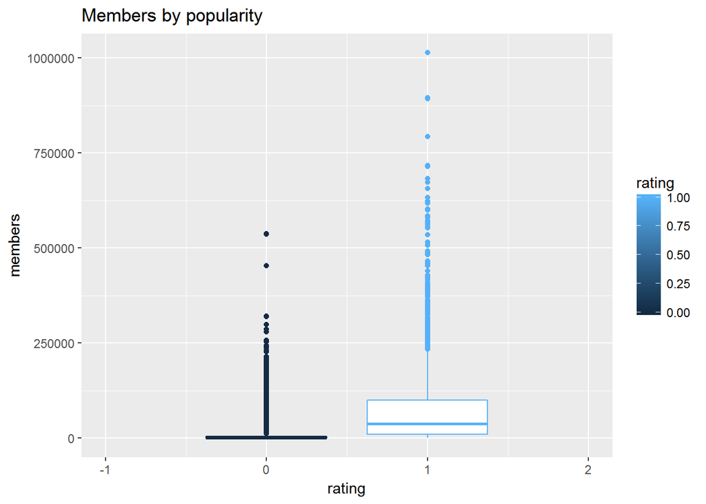

```r
    #Drawing the members variable
    g2 <- ggplot(anime, aes(x = rating, y = members, group = rating, col=rating))

    #Defining the plot as a boxplot and drawing it
    g2 + geom_boxplot() + ylab("members") + ggtitle("Members by popularity")+ xlim(-1,2)
```

###### Animes, that have more members are being liked more often than animes with less members.

#### Why the genres were made into cluster?

###### There was 44 diffrent genres in the data and over 2000 unique combination of these. It is too much variables to be used in this model, but I find genre to be one of the key elements in determing if the anime is being liked or not. So I decided to group these 2000 genres in reasonable amount of groups by clustering.

#### How the number of clusters was determined?

###### I used kmeans function with nstart ( the number of random sets chosen) as 30, because I don’t know where the centers are and 10 guesses weren’t enough in my opinion. The iterations was set to 10000 so it was enough too. Then I relied on human inteligence in valuing the number of clusters. I increased the number of clusters untill the genre combinations in each cluster seemed reasonable enough.

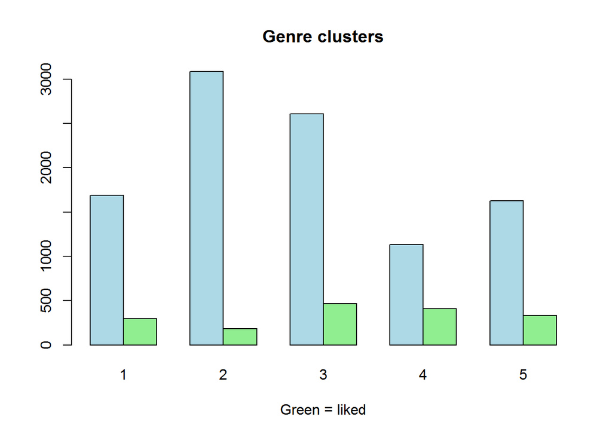

```r
    #Drawing the genre_cluster variable
    counts <- table(anime$rating, anime$genre_cluster)
    barplot(counts , main="Genre clusters", xlab = "Green = liked", col=c( "light blue", "light green"), beside = T)
```

```r
    #Printing out the numbers
    counts
```

```
##
##        1    2    3    4    5
##   0 1688 3087 2607 1136 1625
##   1  296  183  465  411  332
```

###### The human relationship (4) animes seem to be the most popular ones.

# Logistic regression model

###### In this case, model tries to predict wether certain anime belongs to the category of liked (1) or not liked (0) based on the explanotory variables.

# Making the model and validating it

```r
    #Adding libraries
    library(dplyr)
    library(tidyr)

    #Making the model
    m <- glm(rating ~ episodes+members+genre_cluster+type+0, data = anime, family = "binomial")
    summary(m)
```

```
##
## Call:
## glm(formula = rating ~ episodes + members + genre_cluster + type +
##     0, family = "binomial", data = anime)
##
## Deviance Residuals:
##     Min       1Q   Median       3Q      Max
## -5.1699  -0.4636  -0.3885  -0.3223   2.7976
##
## Coefficients:
##                 Estimate Std. Error z value Pr(>|z|)
## episodes       1.700e-03  4.657e-04   3.649 0.000263 ***
## members        2.914e-05  9.612e-07  30.316  < 2e-16 ***
## genre_cluster  1.882e-01  2.301e-02   8.180 2.83e-16 ***
## typeMovie     -2.597e+00  9.529e-02 -27.257  < 2e-16 ***
## typeMusic     -4.327e+00  3.240e-01 -13.355  < 2e-16 ***
## typeONA       -3.943e+00  2.210e-01 -17.841  < 2e-16 ***
## typeOVA       -3.137e+00  9.528e-02 -32.923  < 2e-16 ***
## typeSpecial   -3.060e+00  1.106e-01 -27.671  < 2e-16 ***
## typeTV        -3.214e+00  1.041e-01 -30.883  < 2e-16 ***
## ---
## Signif. codes:  0 '***' 0.001 '**' 0.01 '*' 0.05 '.' 0.1 ' ' 1
##
## (Dispersion parameter for binomial family taken to be 1)
##
##     Null deviance: 16399.9  on 11830  degrees of freedom
## Residual deviance:  7325.6  on 11821  degrees of freedom
## AIC: 7343.6
##
## Number of Fisher Scoring iterations: 6
```

##### From this summary we can quite safely assume that all the explanotory variables do affect the rating.

## Model validation with odd ratios and their intervals

```r
    #Computing th odds ratios (OR).
    OR <- coef(m) %>% exp

    #Computing the confidence intervals (CI)
    CI <- confint(m) %>% exp
    #Printing out the odds ratios with their confidence intervals
     cbind(OR, CI)
```

```
##                       OR       2.5 %     97.5 %
## episodes      1.00170104 1.000750610 1.00263199
## members       1.00002914 1.000027284 1.00003105
## genre_cluster 1.20712601 1.153938482 1.26288420
## typeMovie     0.07447647 0.061674149 0.08960855
## typeMusic     0.01321019 0.006537713 0.02359527
## typeONA       0.01938166 0.012271649 0.02928169
## typeOVA       0.04340949 0.035943051 0.05222200
## typeSpecial   0.04686560 0.037625863 0.05805402
## typeTV        0.04020894 0.032726774 0.04921327
```

## Model validation with cross tabulations

```r
    #Predicting with predict() the probability of anime being liked (=1)
    probabilities <- predict(m, type = "response")

     #Adding the predicted probabilities to 'anime'
     anime <- cbind(anime, probability = probabilities)

     #Using the probabilities to make a prediction of anime rating

     anime <- cbind(anime, prediction = anime$probability > .5)

     #Cross tabulating the target variable versus the predictions
     table(rating = anime$rating, prediction = anime$probability > .5 )
```

```
##       prediction
## rating FALSE TRUE
##      0  9964  179
##      1  1181  506
```

```r
     #Same with precentages
     table(rating = anime$rating, prediction = anime$prediction) %>% prop.table()%>%addmargins()
```

```
##       prediction
## rating      FALSE       TRUE        Sum
##    0   0.84226543 0.01513102 0.85739645
##    1   0.09983094 0.04277261 0.14260355
##    Sum 0.94209637 0.05790363 1.00000000
```

## Over all error of the model

```r
     #Defining a loss function to calculate average prediction error
     loss_func <- function(class, prob) {
     n_wrong <- abs(class - prob) > 0.5
     mean(n_wrong)
     }

    #Computing the average number of wrong predictions in the training data
     loss_func(anime$rating, anime$probability)
```

```
## [1] 0.114962
```

```r
    #K-fold cross-validation
    library(boot)
    cv <- cv.glm(data = anime, cost = loss_func, glmfit = m, K = 10)

    #Average number of wrong predictions in the cross validation
     cv$delta[1]
```

```
## [1] 0.115131
```

##### Training error is less than 12 %, so the model works pretty well.

# Conclusion and discussion

[figure not shown]

```r
    #Drawing the results
    counts2 <- table(anime$rating, anime$prediction)
    barplot(counts2 , main="Prediction vs. actual", xlab = "Black = wrong prediction", col=c( "yellow", "black"),beside = T)
```

##### This model would suggest that human relationship animes are the most popular ones. The clustering of the anime genres has room for an improvment, because it doesn’t catch all the finest diffrences between animes. Also, the relationship between episodes and ranking might not be so simple. GLM doesn’t like factors, so the type variable coud be dealed with some other way. More members did correlate positively with anime being liked, but mystery/sci-fi animes weren’t the most popular ones.